# The Impact of Technology Access on Earnigs

Group 06

January 17, 2019

With a past of racial inequality in the southern states it would be interesting to examine how race/ethnicity is related to access to the internet and other technologies and how not having or having access could effect a persons earnings. This can be explored via the following research questions: In the state of Alabama, how to earnings vary by access to the internet/technology? Does the internet/technology premium vary by race and ethnicity?

# Step_1: System Setup

Before starting the program we need to clean the environment and import the library. The loaded librariesin the code are: 1. tidyverse 2. here 3. DataExplorer

# Step_2: Import Data

## Step_2.1: Import personal income Data

Here we will import the raw data of personal income (ss16pal) into the dataframe as “base”

```r
#load the persional data to variable Base
base <- read_csv(here('raw_data','ss16pal.csv'))%>%
  select(SERIALNO, #Serial Number to link House Hold and Personal data
         AGEP,  # Age: 0#99
         CIT,   # Citizenship status
         COW,   # Class of worker
         DDRS,  # Self#care difficulty
         DEAR,  # Hearing difficulty
         DEYE,  # Vision difficulty
         DOUT,  # Independent living difficulty
         DPHY,  # Ambulatory difficulty
         DRAT,  # Veteran service connected disability rating (percentage)
         DRATX, # Veteran service connected disability rating (checkbox)
         DREM,  # Cognitive difficulty
         ENG,   # Ability to speak English
         JWMNP, # Travel time to work
         JWRIP, # Vehicle occupancy
         JWTR,  # Means of transportation to work
         MAR,   # Marital status
         MIL,   # Military service
         NWLK,  # Looking for work
         SCHL,  # Educational attainment
         SEMP,  # Self-employment income past 12 months (signed)
         SEX,   # Sex
         WAGP,  # Wages or salary income past 12 months
         ESR,   # Employment status recode
         HISP,  # Recoded detailed Hispanic origin
         NATIVITY,  # Nativity
         PERNP, # Total person's earnings
         RAC1P, # Recoded detailed race code
         RACAIAN, # American Indian and Alaska Native recode
         RACASN,  # Asian recode
         RACBLK,  # Black or African American recode
         RACNH, # Native Hawaiian recode
         RACWHT,  # White recode
         WAOB,  # World area of birth
         WKW)   #Weeks worked during past 12 months
```

## Step_2.2: Import household Data

We need to import the household level information (ss16hal) about technology access and merge the data into “base”

```r
#Link the house hould data
househould <- read_csv(here('raw_data','ss16hal.csv'))%>%
  select(SERIALNO, #Serial Number to link House Hold and Personal data
         TYPE, # Type of house
         ACCESS, # Access to the Internet
         BROADBND, # Cellular data plan for a smartphone or other mobile device
         COMPOTHX, # Other computer equipment
         HISPEED, #Broadband (high speed) Internet service such as cable, fiber optic, or DSL service
         LAPTOP, # Laptop or desktop
         OTHSVCEX, # Other Internet service
         SATELLITE, # Satellite Internet service
         SMARTPHONE, # Smartphone
         TABLET # Tablet or other portable wireless computer
  )
base <- base %>% left_join(househould) %>% select(-SERIALNO)
rm(househould)
```

# Step_3: First look of data structure.

```r
str(base)
```

```
## Classes 'spec_tbl_df', 'tbl_df', 'tbl' and 'data.frame': 47659 obs. of  44 variables:
##  $ AGEP      : chr  "84" "84" "78" "46" ...
##  $ CIT       : num  1 1 1 1 1 1 1 1 1 1 ...
##  $ COW       : num  NA NA 1 1 NA NA NA 8 NA 1 ...
##  $ DDRS      : num  2 2 2 2 2 2 2 2 2 2 ...
##  $ DEAR      : num  2 2 2 2 2 2 2 2 2 2 ...
##  $ DEYE      : num  2 2 2 2 2 2 2 2 2 2 ...
##  $ DOUT      : num  2 2 2 2 2 2 2 2 2 2 ...
##  $ DPHY      : num  2 2 2 2 2 2 2 2 2 2 ...
##  $ DRAT      : num  NA NA NA NA NA NA NA NA NA NA ...
##  $ DRATX     : num  NA NA NA 2 NA NA NA NA 2 NA ...
##  $ DREM      : num  2 2 2 2 2 2 2 2 2 2 ...
##  $ ENG       : num  NA NA NA NA NA NA NA NA NA NA ...
##  $ JWMNP     : chr  NA NA "050" "020" ...
##  $ JWRIP     : chr  NA NA "01" "01" ...
```

[output cut: 30 more lines]

# Step_4: Converting data

Convert the categorical data into factor type and numetical data into numeric type. The factorial data in this dataframe will keep its representative code instead of the category name to save the memory space.

```r
#conver the catagorical variable type
base <- base %>% mutate(CIT = as.factor(CIT),
                        COW = as.factor(COW),
                        DDRS = as.factor(DDRS),
                        DEAR = as.factor(DEAR),
                        DEYE = as.factor(DEYE),
                        DOUT = as.factor(DOUT),
                        DPHY = as.factor(DPHY),
                        DRAT = as.factor(DRAT),
                        DRATX = as.factor(DRATX),
                        DREM = as.factor(DREM),
                        ENG = as.factor(ENG),
                        JWRIP = as.factor(JWRIP),
                        JWTR = as.factor(JWTR),
                        MAR = as.factor(MAR),
                        MIL = as.factor(MIL),
                        NWLK = as.factor(NWLK),
                        SCHL = as.factor(SCHL),
                        SEX = as.factor(SEX),
                        ESR = as.factor(ESR),
                        HISP= as.factor(HISP),
                        RAC1P= as.factor(RAC1P),
                        RACAIAN = as.factor(RACAIAN),
                        RACASN = as.factor(RACASN),
                        RACBLK = as.factor(RACBLK),
                        RACNH = as.factor(RACNH),
                        RACWHT = as.factor(RACWHT),
                        WAOB = as.factor(WAOB),
                        WKW = as.factor(WKW),
                        TYPE = as.factor(TYPE),
                        ACCESS = as.factor(ACCESS),
                        BROADBND = as.factor(BROADBND),
                        COMPOTHX = as.factor(COMPOTHX),
                        HISPEED = as.factor(HISPEED),
                        LAPTOP = as.factor(LAPTOP),
                        OTHSVCEX = as.factor(OTHSVCEX),
                        SATELLITE = as.factor(SATELLITE),
                        SMARTPHONE = as.factor(SMARTPHONE),
                        TABLET = as.factor(TABLET)
                        )

#conver the numeric variable type
base <- base %>% mutate(AGEP = as.numeric(AGEP),
                        JWMNP = as.numeric(JWMNP),
                        SEMP= as.numeric(SEMP),
                        WAGP= as.numeric(WAGP),
                        PERNP= as.numeric(PERNP)
                        )
```

Replace the factor level to the choices in the survery question for easy understanding.

```r
levels(base$ACCESS) <- convertCSV2Factor("ACCESS")
levels(base$BROADBND) <- convertCSV2Factor("BROADBND")
levels(base$CIT) <- convertCSV2Factor("CIT")
levels(base$COMPOTHX) <- convertCSV2Factor("COMPOTHX")
levels(base$COW) <- convertCSV2Factor("COW")
levels(base$DDRS) <- convertCSV2Factor("DDRS")
levels(base$DEAR) <- convertCSV2Factor("DEAR")
levels(base$DEYE) <- convertCSV2Factor("DEYE")
levels(base$DOUT) <- convertCSV2Factor("DOUT")
levels(base$DOUT) <- convertCSV2Factor("DOUT")
levels(base$DPHY) <- convertCSV2Factor("DPHY")
levels(base$DRAT) <- convertCSV2Factor("DRAT")
levels(base$DRATX) <- convertCSV2Factor("DRATX")
levels(base$DREM) <- convertCSV2Factor("DREM")
levels(base$ENG) <- convertCSV2Factor("ENG")
levels(base$ESR) <- convertCSV2Factor("ESR")
levels(base$HISP) <- convertCSV2Factor("HISP")
levels(base$HISPEED) <- convertCSV2Factor("HISPEED")
levels(base$JWRIP) <- convertCSV2Factor("JWRIP")
levels(base$JWTR) <- convertCSV2Factor("JWTR")
levels(base$LAPTOP) <- convertCSV2Factor("LAPTOP")
levels(base$MAR) <- convertCSV2Factor("MAR")
levels(base$MIL) <- convertCSV2Factor("MIL")
levels(base$NWLK) <- convertCSV2Factor("NWLK")
levels(base$OTHSVCEX) <- convertCSV2Factor("OTHSVCEX")
levels(base$RAC1P) <- convertCSV2Factor("RAC1P")
levels(base$RACAIAN) <- convertCSV2Factor("RACAIAN")
levels(base$RACASN) <- convertCSV2Factor("RACASN")
levels(base$RACBLK) <- convertCSV2Factor("RACBLK")
levels(base$RACNH) <- convertCSV2Factor("RACNH")
levels(base$RACWHT) <- convertCSV2Factor("RACWHT")
levels(base$SATELLITE) <- convertCSV2Factor("SATELLITE")
levels(base$SCHL) <- convertCSV2Factor("SCHL")
levels(base$SEX) <- convertCSV2Factor("SEX")
levels(base$SMARTPHONE) <- convertCSV2Factor("SMARTPHONE")
levels(base$TABLET) <- convertCSV2Factor("TABLET")
levels(base$WAOB) <- convertCSV2Factor("WAOB")
levels(base$WKW) <- convertCSV2Factor("WKW")
```

==================

# Step_5: Exploratory data analysis - EDA

## Step_5.1 EDA - Data Structure

```r
str(base)
```

```
## Classes 'tbl_df', 'tbl' and 'data.frame':    47659 obs. of  44 variables:
##  $ AGEP      : num  84 84 78 46 52 20 16 66 68 64 ...
##  $ CIT       : Factor w/ 5 levels "Born in the U.S.",..: 1 1 1 1 1 1 1 1 1 1 ...
##  $ COW       : Factor w/ 9 levels "Employee of a private for-profit company or business, or of an individual,  for wages, salary,  or commissions",..: NA NA 1 1 NA NA NA 8 NA 1 ...
##  $ DDRS      : Factor w/ 2 levels "Yes","No": 2 2 2 2 2 2 2 2 2 2 ...
##  $ DEAR      : Factor w/ 2 levels "Yes","No": 2 2 2 2 2 2 2 2 2 2 ...
##  $ DEYE      : Factor w/ 2 levels "Yes","No": 2 2 2 2 2 2 2 2 2 2 ...
##  $ DOUT      : Factor w/ 2 levels "Yes","No": 2 2 2 2 2 2 2 2 2 2 ...
##  $ DPHY      : Factor w/ 2 levels "Yes","No": 2 2 2 2 2 2 2 2 2 2 ...
##  $ DRAT      : Factor w/ 6 levels "0 percent","10 or 20 percent",..: NA NA NA NA NA NA NA NA NA NA ...
##  $ DRATX     : Factor w/ 2 levels "Yes","No": NA NA NA 2 NA NA NA NA 2 NA ...
##  $ DREM      : Factor w/ 2 levels "Yes","No": 2 2 2 2 2 2 2 2 2 2 ...
##  $ ENG       : Factor w/ 4 levels "Very well","Well",..: NA NA NA NA NA NA NA NA NA NA ...
##  $ JWMNP     : num  NA NA 50 20 NA NA NA NA NA 15 ...
##  $ JWRIP     : Factor w/ 10 levels "Drove alone",..: NA NA 1 1 NA NA NA NA NA 1 ...
```

[output cut: 30 more lines]

## Step_5.2 EDA - Data Summary

```r
summary(base)
```

```
##       AGEP
##  Min.   : 0.00
##  1st Qu.:22.00
##  Median :44.00
##  Mean   :42.54
##  3rd Qu.:62.00
##  Max.   :93.00
##
##                                                                               CIT
##  Born in the U.S.                                                               :45947
##  Born in Puerto Rico,  Guam,  the U.S. Virgin Islands,  or the Northern Marianas:   62
##  Born abroad of American parent(s)                                              :  315
##  U.S. citizen by naturalization                                                 :  585
##  Not a citizen of the U.S.                                                      :  750
##
##
##                                                                                                              COW
##  Employee of a private for-profit company or business, or of an individual,  for wages, salary,  or commissions:17266
##  Employee of a private not-for-profit,  tax-exempt,  or charitable organization                                : 1851
##  Local government employee (city,  county,  etc.)                                                              : 1765
##  State government employee                                                                                     : 1514
##  Self-employed in own not incorporated business,  professional practice,  or farm                              : 1502
##  (Other)                                                                                                       : 2241
##  NA's                                                                                                          :21520
##    DDRS        DEAR        DEYE         DOUT         DPHY
##  Yes : 2121   Yes: 2453   Yes: 1787   Yes : 3713   Yes : 5473
##  No  :43191   No :45206   No :45872   No  :36349   No  :39839
##  NA's: 2347                           NA's: 7597   NA's: 2347
##
##
##
##
##                          DRAT        DRATX         DREM
##  0 percent                 :   46   Yes : 1017   Yes : 3497
##  10 or 20 percent          :  267   No  : 3587   No  :41815
##  30 or 40 percent          :  167   NA's:43055   NA's: 2347
##  50 or 60 percent          :  131
##  70, 80, 90, or 100 percent:  358
##  Not reported              :   48
##  NA's                      :46642
```

[output cut: 105 more lines]

```
##  Yes :31969   Yes : 1035   Yes :28048   Yes :33811   Yes :  484
##  No  : 4990   No  :44312   No  : 8911   No  :11536   No  :36475
##  NA's:10700   NA's: 2312   NA's:10700   NA's: 2312   NA's:10700
##
##
##
##
##  SATELLITE    SMARTPHONE    TABLET
##  Yes : 3898   Yes :34685   Yes :27043
##  No  :33061   No  :10662   No  :18304
##  NA's:10700   NA's: 2312   NA's: 2312
##
##
##
##
```

## Step_5.3 EDA - Age:

```r
base %>% select(AGEP) %>%  summary()
```

```
##       AGEP
##  Min.   : 0.00
##  1st Qu.:22.00
##  Median :44.00
##  Mean   :42.54
##  3rd Qu.:62.00
##  Max.   :93.00
```

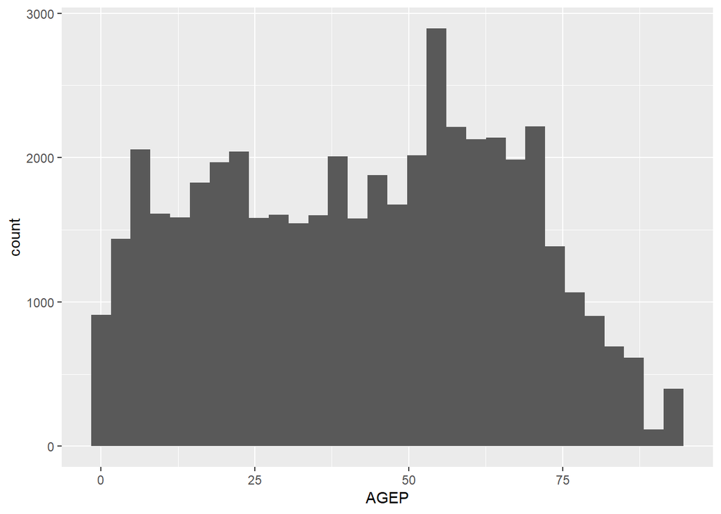

```r
base %>% ggplot(aes(AGEP)) + geom_histogram()
```

```r
base <- base %>%  filter(AGEP>=16 & AGEP <= 60)
base %>% select(AGEP) %>%  summary()
```

```
##       AGEP
##  Min.   :16.00
##  1st Qu.:27.00
##  Median :40.00
##  Mean   :39.06
##  3rd Qu.:51.00
##  Max.   :60.00
```

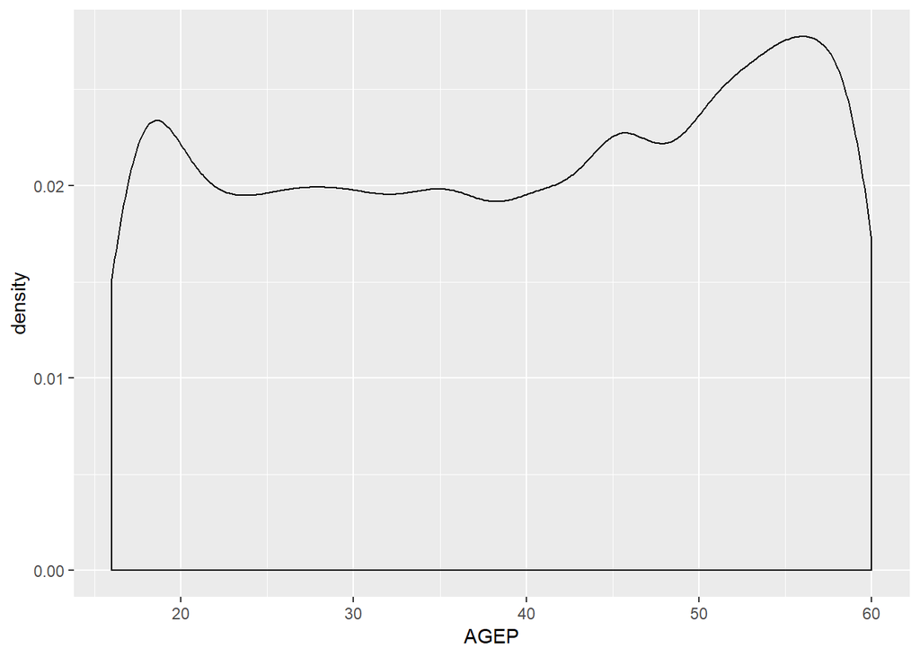

```r
base %>% ggplot(aes(AGEP)) + geom_density()
```

## Step_5.4 EDA - Labor:

We decided to exclude people:  
1. Working without pay in family business or farm  
2. Unemployed and last worked 5 years ago or earlier or never worked

```r
base <- base %>%  filter(as.integer(COW)<8)
```

3. Worked less than 50 weeks in the last 12 months

```r
base <- base %>%  filter(as.integer(WKW)==1)
```

## Step_5.5 EDA - Wage:

Since the focus of our analysis is access to technology we can restrict the data by removing the rich and upper middle class (setting the max at the 3rd Quartile) because at a certain wage level we can conclude that technology becomes more about choice than access.

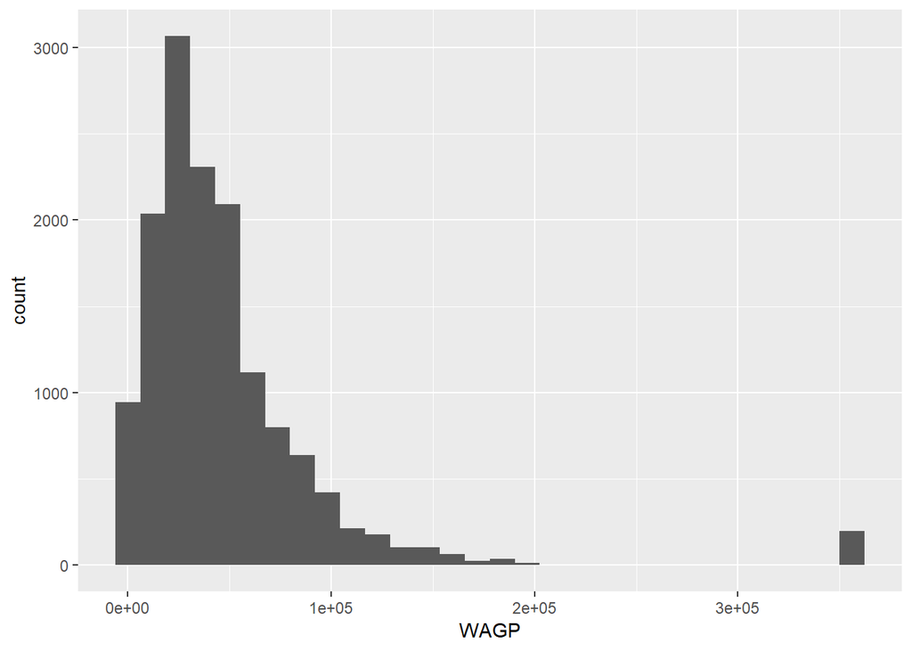

```r
base  %>% ggplot(aes(WAGP)) + geom_histogram()
```

```r
base <- base %>%  filter(WAGP<54000 & WAGP > 1000)
summary(base$WAGP)
```

```
##    Min. 1st Qu.  Median    Mean 3rd Qu.    Max.
##    1100   18200   28000   28789   40000   53000
```

Our earnings distributions after this considerations is:

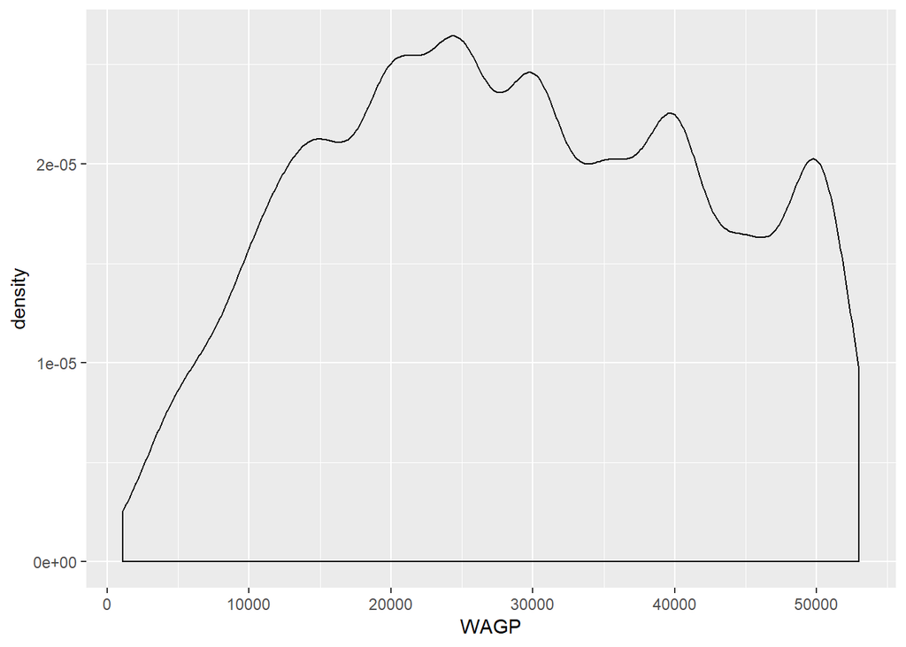

```r
base  %>% ggplot(aes(WAGP)) + geom_density()
```

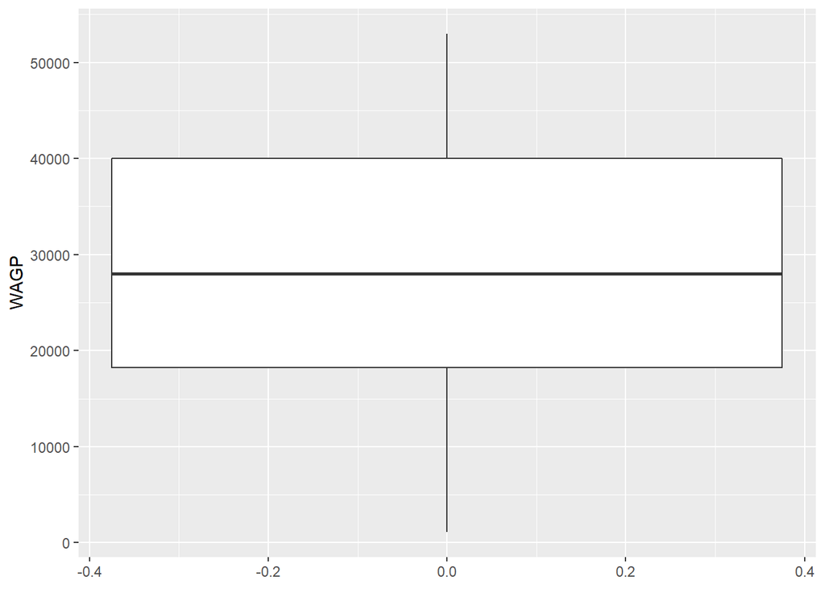

```r
base  %>% ggplot(aes(y=WAGP)) + geom_boxplot()
```

## Step_5.5 EDA - Missing data:

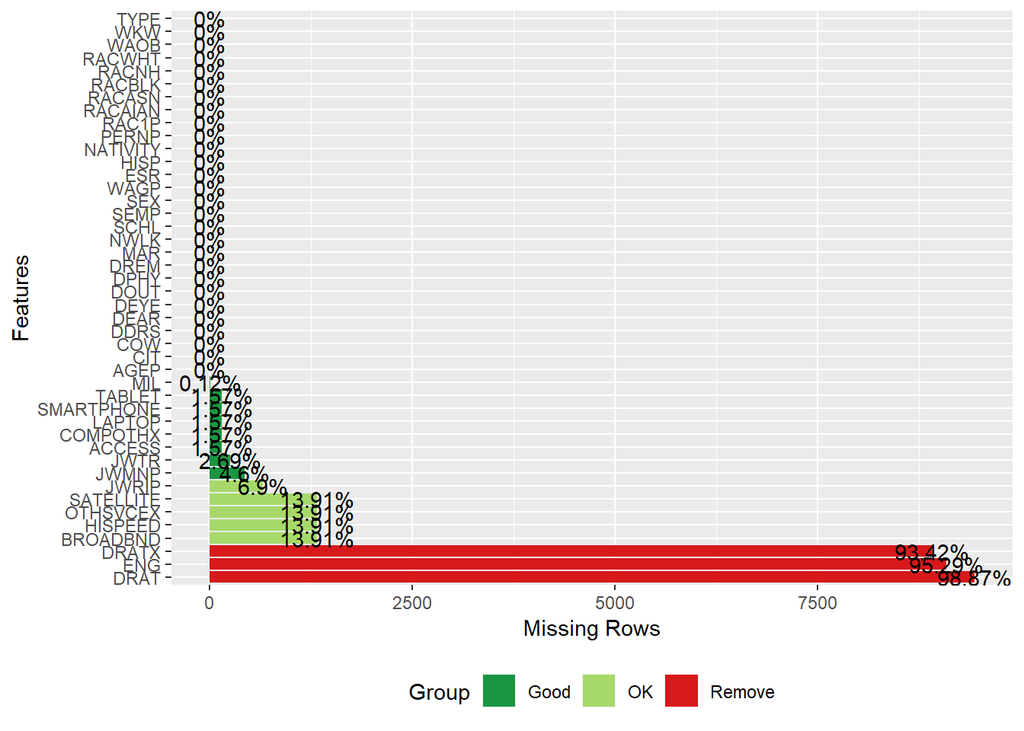

```r
plot_missing(base)
```

Since the variable of “DRATX”, “ENG”, “DRAT” have numerous missing data that lead these three vairable as “un-representative,” so this study will remove these three variables.

```r
base$DRAT <- NULL
base$ENG <- NULL
base$DRATX <- NULL
```

# Step_6: Exploratory data analysis after restrictions

```r
summary(base)
```

```
##       AGEP
##  Min.   :16.00
##  1st Qu.:29.00
##  Median :39.00
##  Mean   :39.39
##  3rd Qu.:50.00
##  Max.   :60.00
##
##                                                                               CIT
##  Born in the U.S.                                                               :9083
##  Born in Puerto Rico,  Guam,  the U.S. Virgin Islands,  or the Northern Marianas:   9
##  Born abroad of American parent(s)                                              :  81
##  U.S. citizen by naturalization                                                 : 127
##  Not a citizen of the U.S.                                                      : 239
##
##
##                                                                                                              COW
##  Employee of a private for-profit company or business, or of an individual,  for wages, salary,  or commissions:6906
##  Local government employee (city,  county,  etc.)                                                              : 781
##  Employee of a private not-for-profit,  tax-exempt,  or charitable organization                                : 756
##  State government employee                                                                                     : 585
##  Self-employed in own incorporated business,  professional practice or farm                                    : 249
##  Federal government employee                                                                                   : 226
##  (Other)                                                                                                       :  36
##   DDRS       DEAR       DEYE       DOUT       DPHY       DREM
##  Yes:  46   Yes: 145   Yes: 166   Yes:  84   Yes: 219   Yes: 180
##  No :9493   No :9394   No :9373   No :9455   No :9320   No :9359
##
##
##
##
##
##      JWMNP                        JWRIP                      JWTR
##  Min.   :  1.00   Drove alone        :8039   Car, truck, or van:8881
##  1st Qu.: 10.00   In 2-person carpool: 666   Worked at home    : 182
##  Median : 20.00   In 3-person carpool: 104   Walked            : 117
##  Mean   : 23.89   In 4-person carpool:  41   Other method      :  49
##  3rd Qu.: 30.00   In 5-person carpool:  16   Bus or trolley bus:  29
##  Max.   :125.00   (Other)            :  15   (Other)           :  24
##  NA's   :439      NA's               : 658   NA's              : 257
```

[output cut: 89 more lines]

```
##  Yes :7421   Yes : 197   Yes :6124   Yes :7332   Yes : 104   Yes : 774
##  No  : 791   No  :9192   No  :2088   No  :2057   No  :8108   No  :7438
##  NA's:1327   NA's: 150   NA's:1327   NA's: 150   NA's:1327   NA's:1327
##
##
##
##
##  SMARTPHONE   TABLET
##  Yes :8090   Yes :5994
##  No  :1299   No  :3395
##  NA's: 150   NA's: 150
##
##
##
##
```

==================

# Step_7: Examine access to the internet and its relation to earnings.

```r
base %>% select(ACCESS) %>% summary()
```

```
##                                                                    ACCESS
##  Yes, by paying a cell phone company or Internet service provider     :8212
##  Yes, without paying a cell phone company or Internet service provider: 247
##  No access to the Internet at this house, apartment, or mobile home   : 930
##  NA's                                                                 : 150
```

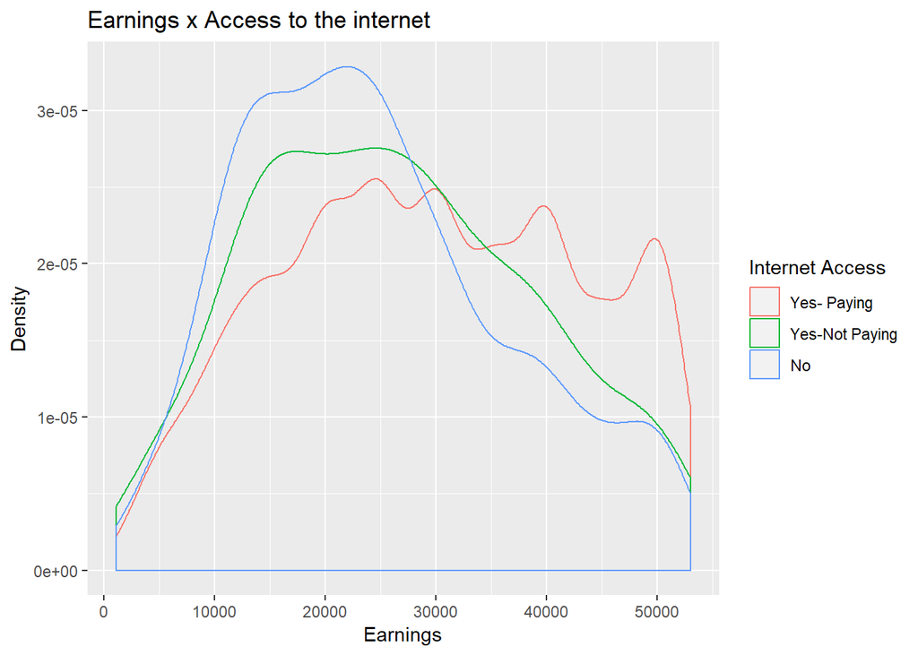

```r
base %>%  filter(!is.na(ACCESS)) %>%
  ggplot(aes(WAGP,color=ACCESS)) + geom_density() +
  labs(title="Earnings x Access to the internet",
       x ="Earnings", y = "Density") +
  scale_color_discrete(name="Internet Access",
                      labels=c("Yes- Paying", "Yes-Not Paying", "No"))
```

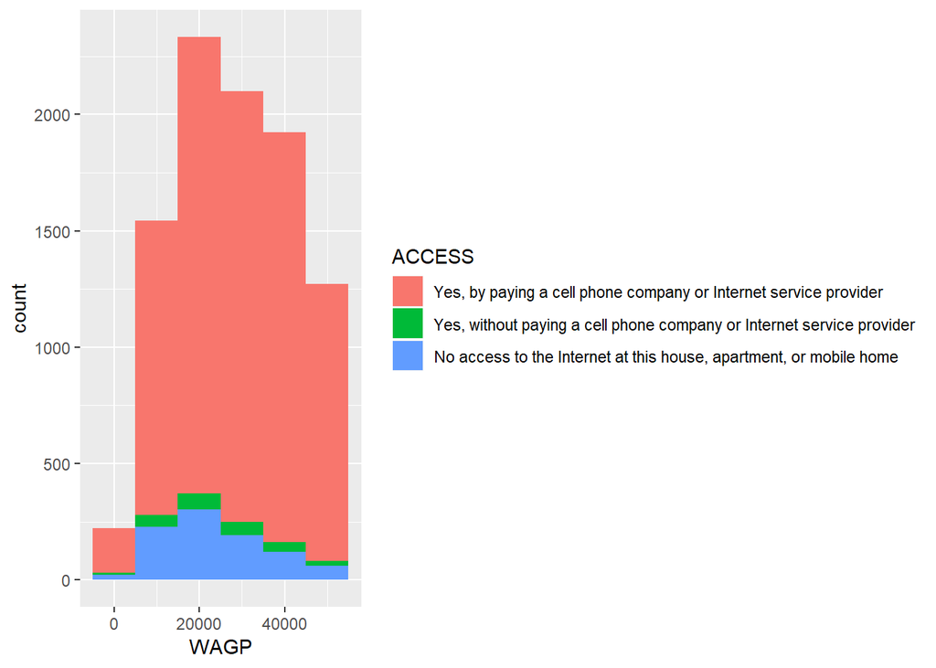

```r
base %>%  filter(!is.na(ACCESS)) %>%
  ggplot() + geom_histogram(aes(x=WAGP,fill=ACCESS), binwidth = 10000)
```

## Step_7.1 Using Tablet as a proxy of Technology Access

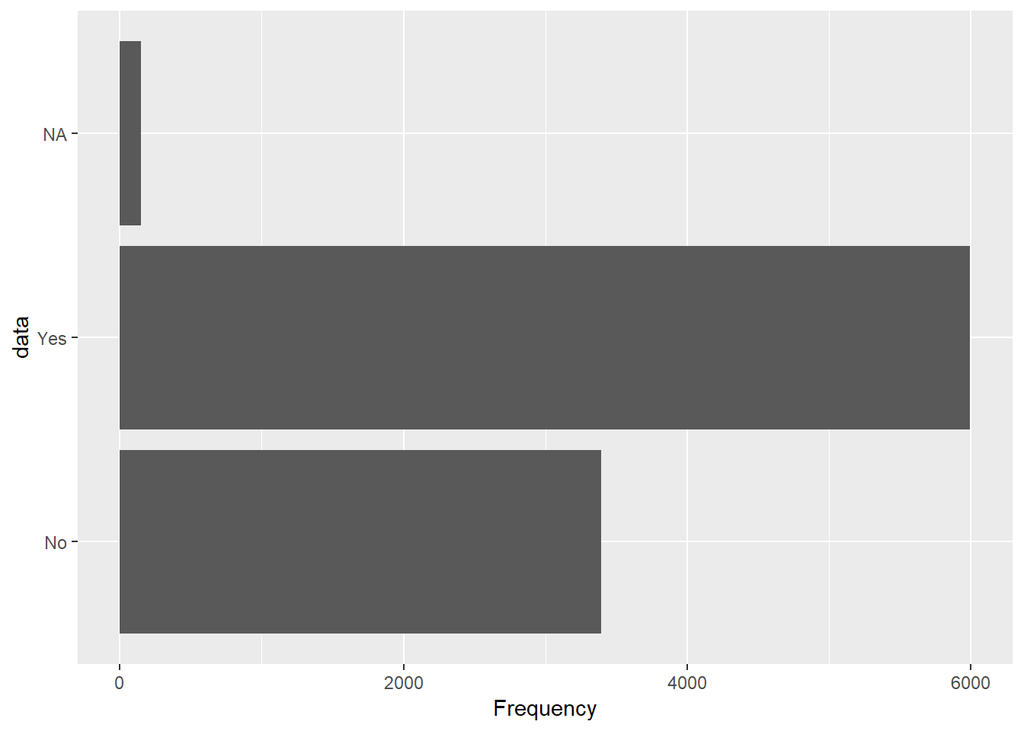

```r
#base %>% select(TABLET) %>% summary()
plot_bar(base$TABLET)
```

```r
base %>% filter(TABLET=="Yes") %>% select(WAGP) %>% summary() #person have tablet
```

```
##       WAGP
##  Min.   : 1100
##  1st Qu.:20000
##  Median :30000
##  Mean   :30054
##  3rd Qu.:40000
##  Max.   :53000
```

```r
base %>% filter(TABLET=="No") %>% select(WAGP) %>% summary() #person doesn't have tablet
```

```
##       WAGP
##  Min.   : 1200
##  1st Qu.:17000
##  Median :25100
##  Mean   :27248
##  3rd Qu.:37000
##  Max.   :53000
```

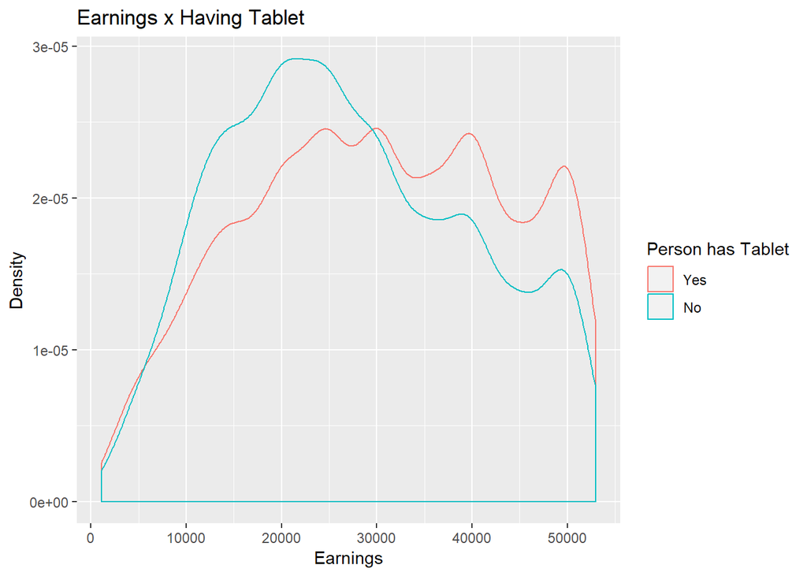

```r
base %>%  filter(!is.na(TABLET)) %>%
  ggplot(aes(WAGP,color=TABLET)) + geom_density() +
  labs(title="Earnings x Having Tablet",
       x ="Earnings", y = "Density") +
  scale_color_discrete(name="Person has Tablet",
                      labels=c("Yes", "No"))
```

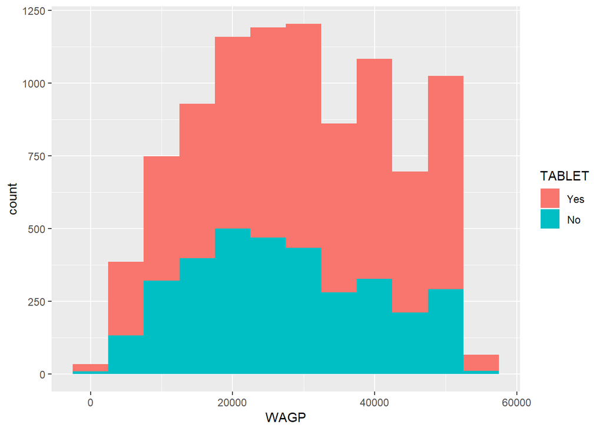

```r
base %>%  filter(!is.na(TABLET)) %>%
  ggplot() + geom_histogram(aes(x=WAGP,fill=TABLET), binwidth = 5000)
```

## Step_7.2 Using Smartphone as a proxy of Technology Access

```r
base %>% select(SMARTPHONE) %>% summary()
```

```
##  SMARTPHONE
##  Yes :8090
##  No  :1299
##  NA's: 150
```

```r
base %>% filter(SMARTPHONE=="Yes") %>% select(WAGP) %>% summary() #person have smartphone
```

```
##       WAGP
##  Min.   : 1100
##  1st Qu.:20000
##  Median :30000
##  Mean   :29518
##  3rd Qu.:40000
##  Max.   :53000
```

```r
base %>% filter(SMARTPHONE=="No") %>% select(WAGP) %>% summary() #person doesn't have smartphone
```

```
##       WAGP
##  Min.   : 1100
##  1st Qu.:15150
##  Median :25000
##  Mean   :26063
##  3rd Qu.:36000
##  Max.   :53000
```

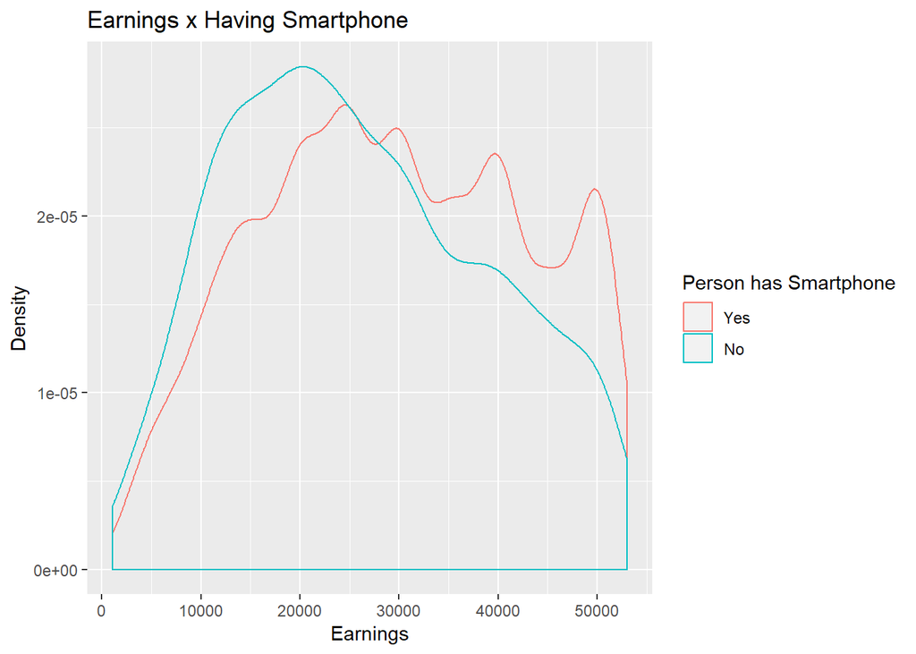

```r
base %>%  filter(!is.na(SMARTPHONE)) %>%
  ggplot(aes(WAGP,color=SMARTPHONE)) + geom_density() +
  labs(title="Earnings x Having Smartphone",
       x ="Earnings", y = "Density") +
  scale_color_discrete(name="Person has Smartphone",
                      labels=c("Yes", "No"))
```

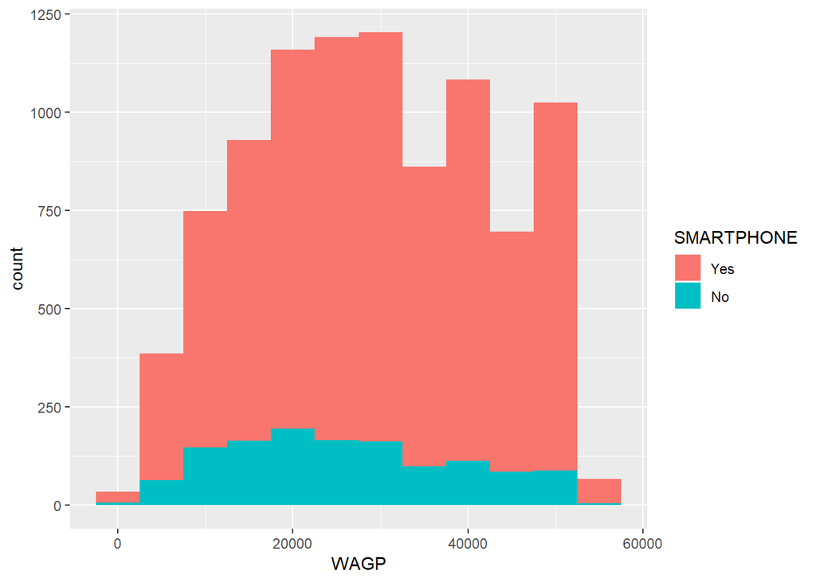

```r
base %>%  filter(!is.na(SMARTPHONE)) %>%
  ggplot() + geom_histogram(aes(x=WAGP,fill=SMARTPHONE), binwidth = 5000)
```

## Step_7.3 Using Laptop as a proxy of Technology Access

```r
base %>% select(LAPTOP) %>% summary()
```

```
##   LAPTOP
##  Yes :7332
##  No  :2057
##  NA's: 150
```

```r
base %>% filter(LAPTOP=="Yes") %>% select(WAGP) %>% summary() #person have Laptop
```

```
##       WAGP
##  Min.   : 1100
##  1st Qu.:20000
##  Median :30000
##  Mean   :30093
##  3rd Qu.:40000
##  Max.   :53000
```

```r
base %>% filter(LAPTOP=="No") %>% select(WAGP) %>% summary() #person doesn't have Laptop
```

```
##       WAGP
##  Min.   : 1100
##  1st Qu.:15100
##  Median :24000
##  Mean   :25286
##  3rd Qu.:34000
##  Max.   :53000
```

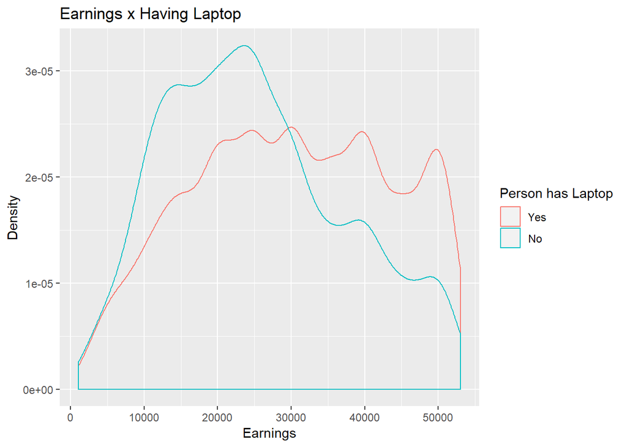

```r
base %>%  filter(!is.na(LAPTOP)) %>%
  ggplot(aes(WAGP,color=LAPTOP)) + geom_density() +
  labs(title="Earnings x Having Laptop",
       x ="Earnings", y = "Density") +
  scale_color_discrete(name="Person has Laptop",
                      labels=c("Yes", "No"))
```

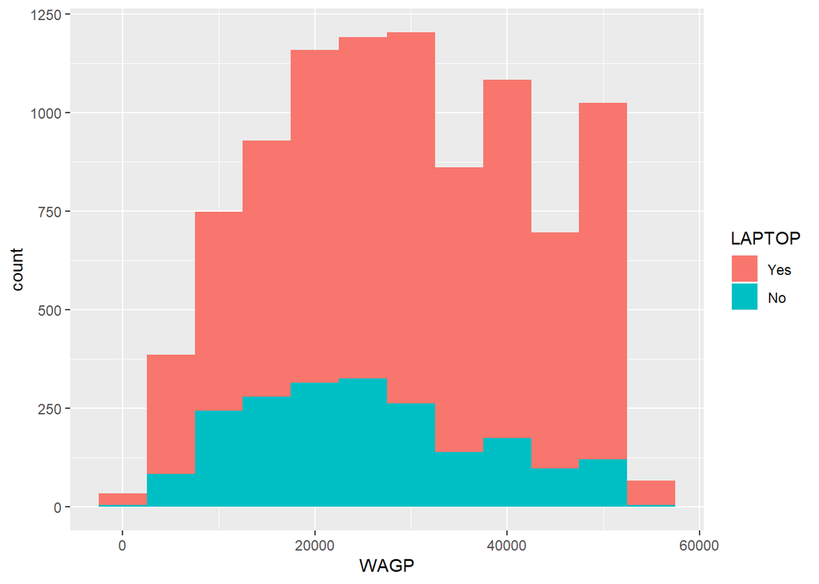

```r
base %>%  filter(!is.na(LAPTOP)) %>%
  ggplot() + geom_histogram(aes(x=WAGP,fill=LAPTOP), binwidth = 5000)
```

## Step_7.4 Using HIGH SPEED Internet as a proxy of Technology Access

```r
base %>% select(HISPEED) %>% summary()
```

```
##  HISPEED
##  Yes :6124
##  No  :2088
##  NA's:1327
```

```r
base %>% filter(HISPEED=="Yes") %>% select(WAGP) %>% summary() #person have HIGH SPEED Internet
```

```
##       WAGP
##  Min.   : 1100
##  1st Qu.:20000
##  Median :30000
##  Mean   :30234
##  3rd Qu.:40300
##  Max.   :53000
```

```r
base %>% filter(HISPEED=="No") %>% select(WAGP) %>% summary() #person doesn't have HIGH SPEED Internet
```

```
##       WAGP
##  Min.   : 1200
##  1st Qu.:18000
##  Median :26400
##  Mean   :27839
##  3rd Qu.:38000
##  Max.   :53000
```

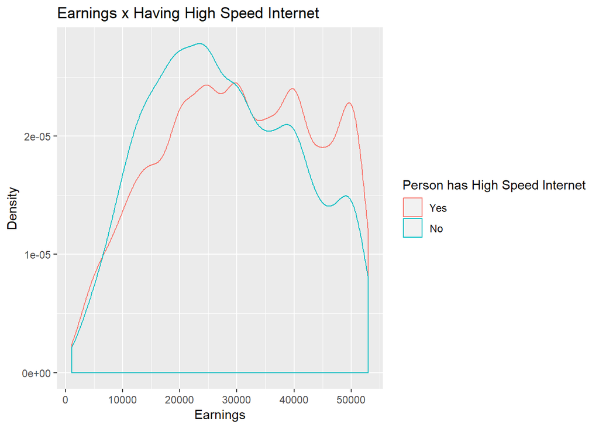

```r
base %>%  filter(!is.na(HISPEED)) %>%
  ggplot(aes(WAGP,color=HISPEED)) + geom_density() +
  labs(title="Earnings x Having High Speed Internet",
       x ="Earnings", y = "Density") +
  scale_color_discrete(name="Person has High Speed Internet",
                      labels=c("Yes", "No"))
```

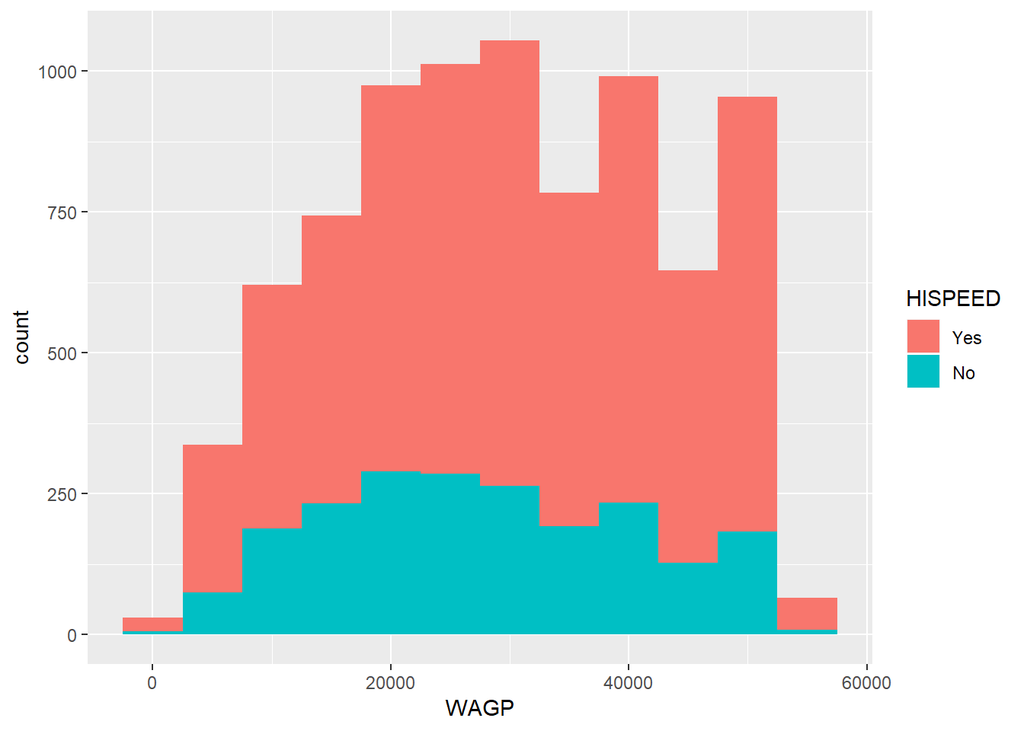

```r
base %>%  filter(!is.na(HISPEED)) %>%
  ggplot() + geom_histogram(aes(x=WAGP,fill=HISPEED), binwidth = 5000)
```

## Step_7.5 Race and access to the internet

```r
base %>% select(RAC1P) %>% summary()
```

```
##                              RAC1P
##  White alone                    :6844
##  Black or African American alone:2297
##  Two or More Races              : 126
##  Some Other Race alone          : 118
##  Asian alone                    :  99
##  American Indian alone          :  42
##  (Other)                        :  13
```

```r
base %>% filter(ACCESS=="No access to the Internet at this house, apartment, or mobile home") %>% select(RAC1P) %>% summary() #person doesn't have ACCESS to Internet
```

```
##                              RAC1P
##  White alone                    :534
##  Black or African American alone:349
##  Some Other Race alone          : 26
##  Two or More Races              : 15
##  American Indian alone          :  3
##  Asian alone                    :  2
##  (Other)                        :  1
```

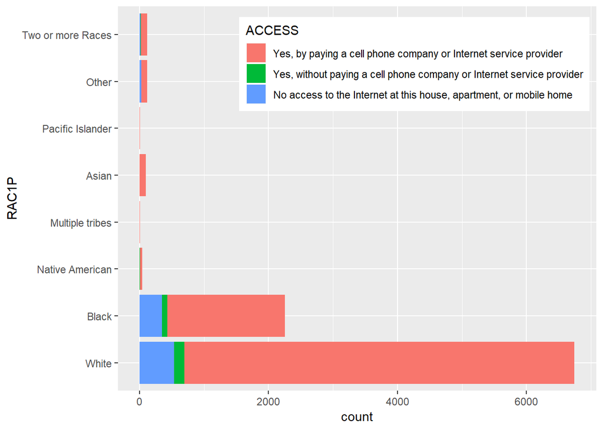

```r
base %>%  filter(!is.na(ACCESS)) %>%
  ggplot() + geom_bar(aes(x = RAC1P, fill=ACCESS)) +
  coord_flip() +
  scale_x_discrete(labels = c('White', 'Black', 'Native American', "Multiple tribes", "Asian", 'Pacific Islander', 'Other', 'Two or more Races')) +
  theme(legend.position= c(0.62,0.85))
```

==================

# Notes on variable selection and restriction

By examining the relationship between earnings and access to technology we are able to see if an individuals earnings are at all effected by their level of access to technology. This is of particular interest when applied to the middle class and working poor. When performing variable selection and restriction, we chose to restrict the age variable to adults of working age from 16 to 60. Additionally, we chose to remove respondents who were working without pay, who are unemployed, or who have worked for less than 50 weeks.

Once we restricted the work related variables, we examined the earnings variable (WAGP). Since our analysis is focused on access to technology we removed the top quartile of earnings. This is because over a certain earnings rate technology acquisition is based more on choice than access. We also restricted the lower rate to $1000, we did this to limit the respondents who claimed to have worked for at least 50 weeks but reported $0 in earnings.